# Das2016analysis

## Create results table

```r
genecount <- nrow(eSet)

# Fit individual contrast
fitcoCE15 <- contrasts.fit(fit, coCE15)
fitcoCE15 <- eBayes(fitcoCE15)
# Perform BH correction
resultscoCE15 <- decideTests(fitcoCE15, adjust.method = "BH")
# Extract results for all probes
tablecoCE15 <- topTable(fitcoCE15, number = genecount)
# Sort table
tablecoCE15 <- tablecoCE15[sort(rownames(tablecoCE15)),]
# Simplify output
tablecoCE15 <- tablecoCE15[,c(1:3, 7)]
# Add unique identifier
colnames(tablecoCE15)[3:4] <- paste(rep("coCE15", 2), colnames(tablecoCE15)[3:4], sep = "_")
# Create rn column for combining all results later
tablecoCE15$rn <- rownames(tablecoCE15)

head(tablecoCE15)
```

```
##          mrna_assignment gene_ID coCE15_logFC coCE15_adj.P.Val       rn
## 13320001             ---     ---  -0.87751000        0.7414009 13320001
## 13320003             ---     ---   0.06657667        0.9986636 13320003
## 13320005             ---     ---  -0.09742667        0.9986636 13320005
## 13320007             ---     ---   0.62402667        0.8901054 13320007
## 13320009             ---     ---   0.13064667        0.9986636 13320009
## 13320011             ---     ---   0.11326333        0.9986636 13320011
```

```r
# Repeat for each contrast
fitcoCS15 <- contrasts.fit(fit, coCS15)
fitcoCS15 <- eBayes(fitcoCS15)
resultscoCS15 <- decideTests(fitcoCS15, adjust.method = "BH")
tablecoCS15 <- topTable(fitcoCS15, number = genecount)
tablecoCS15 <- tablecoCS15[sort(rownames(tablecoCS15)),]
tablecoCS15 <- tablecoCS15[,c(1:3, 7)]
colnames(tablecoCS15)[3:4] <- paste(rep("coCS15", 2), colnames(tablecoCS15)[3:4], sep = "_")
tablecoCS15$rn <- rownames(tablecoCS15)

fitcoCE135 <- contrasts.fit(fit, coCE135)
fitcoCE135 <- eBayes(fitcoCE135)
resultscoCE135 <- decideTests(fitcoCE135, adjust.method = "BH")
tablecoCE135 <- topTable(fitcoCE135, number = genecount)
tablecoCE135 <- tablecoCE135[sort(rownames(tablecoCE135)),]
tablecoCE135 <- tablecoCE135[,c(1:3, 7)]
colnames(tablecoCE135)[3:4] <- paste(rep("coCE135", 2), colnames(tablecoCE135)[3:4], sep = "_")
tablecoCE135$rn <- rownames(tablecoCE135)

fitcoCS135 <- contrasts.fit(fit, coCS135)
fitcoCS135 <- eBayes(fitcoCS135)
resultscoCS135 <- decideTests(fitcoCS135, adjust.method = "BH")
tablecoCS135 <- topTable(fitcoCS135, number = genecount)
tablecoCS135 <- tablecoCS135[sort(rownames(tablecoCS135)),]
tablecoCS135 <- tablecoCS135[,c(1:3, 7)]
colnames(tablecoCS135)[3:4] <- paste(rep("coCS135", 2), colnames(tablecoCS135)[3:4], sep = "_")
tablecoCS135$rn <- rownames(tablecoCS135)

fitcoCE255 <- contrasts.fit(fit, coCE255)
fitcoCE255 <- eBayes(fitcoCE255)
resultscoCE255 <- decideTests(fitcoCE255, adjust.method = "BH")
tablecoCE255 <- topTable(fitcoCE255, number = genecount)
tablecoCE255 <- tablecoCE255[sort(rownames(tablecoCE255)),]
tablecoCE255 <- tablecoCE255[,c(1:3, 7)]
colnames(tablecoCE255)[3:4] <- paste(rep("coCE255", 2), colnames(tablecoCE255)[3:4], sep = "_")
tablecoCE255$rn <- rownames(tablecoCE255)

fitcoCS255 <- contrasts.fit(fit, coCS255)
fitcoCS255 <- eBayes(fitcoCS255)
resultscoCS255 <- decideTests(fitcoCS255, adjust.method = "BH")
tablecoCS255 <- topTable(fitcoCS255, number = genecount)
tablecoCS255 <- tablecoCS255[sort(rownames(tablecoCS255)),]
tablecoCS255 <- tablecoCS255[,c(1:3, 7)]
colnames(tablecoCS255)[3:4] <- paste(rep("coCS255", 2), colnames(tablecoCS255)[3:4], sep = "_")
tablecoCS255$rn <- rownames(tablecoCS255)

fithyCE15 <- contrasts.fit(fit, hyCE15)
fithyCE15 <- eBayes(fithyCE15)
resultshyCE15 <- decideTests(fithyCE15, adjust.method = "BH")
tablehyCE15 <- topTable(fithyCE15, number = genecount)
tablehyCE15 <- tablehyCE15[sort(rownames(tablehyCE15)),]
tablehyCE15 <- tablehyCE15[,c(1:3, 7)]
colnames(tablehyCE15)[3:4] <- paste(rep("hyCE15", 2), colnames(tablehyCE15)[3:4], sep = "_")
tablehyCE15$rn <- rownames(tablehyCE15)

fithyCS15 <- contrasts.fit(fit, hyCS15)
fithyCS15 <- eBayes(fithyCS15)
resultshyCS15 <- decideTests(fithyCS15, adjust.method = "BH")
tablehyCS15 <- topTable(fithyCS15, number = genecount)
tablehyCS15 <- tablehyCS15[sort(rownames(tablehyCS15)),]
tablehyCS15 <- tablehyCS15[,c(1:3, 7)]
colnames(tablehyCS15)[3:4] <- paste(rep("hyCS15", 2), colnames(tablehyCS15)[3:4], sep = "_")
tablehyCS15$rn <- rownames(tablehyCS15)

fithyCE135 <- contrasts.fit(fit, hyCE135)
fithyCE135 <- eBayes(fithyCE135)
resultshyCE135 <- decideTests(fithyCE135, adjust.method = "BH")
tablehyCE135 <- topTable(fithyCE135, number = genecount)
tablehyCE135 <- tablehyCE135[sort(rownames(tablehyCE135)),]
tablehyCE135 <- tablehyCE135[,c(1:3, 7)]
colnames(tablehyCE135)[3:4] <- paste(rep("hyCE135", 2), colnames(tablehyCE135)[3:4], sep = "_")
tablehyCE135$rn <- rownames(tablehyCE135)

fithyCS135 <- contrasts.fit(fit, hyCS135)
fithyCS135 <- eBayes(fithyCS135)
resultshyCS135 <- decideTests(fithyCS135, adjust.method = "BH")
tablehyCS135 <- topTable(fithyCS135, number = genecount)
tablehyCS135 <- tablehyCS135[sort(rownames(tablehyCS135)),]
tablehyCS135 <- tablehyCS135[,c(1:3, 7)]
colnames(tablehyCS135)[3:4] <- paste(rep("hyCS135", 2), colnames(tablehyCS135)[3:4], sep = "_")
tablehyCS135$rn <- rownames(tablehyCS135)

fithyCE255 <- contrasts.fit(fit, hyCE255)
fithyCE255 <- eBayes(fithyCE255)
resultshyCE255 <- decideTests(fithyCE255, adjust.method = "BH")
tablehyCE255 <- topTable(fithyCE255, number = genecount)
tablehyCE255 <- tablehyCE255[sort(rownames(tablehyCE255)),]
tablehyCE255 <- tablehyCE255[,c(1:3, 7)]
colnames(tablehyCE255)[3:4] <- paste(rep("hyCE255", 2), colnames(tablehyCE255)[3:4], sep = "_")
tablehyCE255$rn <- rownames(tablehyCE255)

fithyCS255 <- contrasts.fit(fit, hyCS255)
fithyCS255 <- eBayes(fithyCS255)
resultshyCS255 <- decideTests(fithyCS255, adjust.method = "BH")
tablehyCS255 <- topTable(fithyCS255, number = genecount)
tablehyCS255 <- tablehyCS255[sort(rownames(tablehyCS255)),]
tablehyCS255 <- tablehyCS255[,c(1:3, 7)]
colnames(tablehyCS255)[3:4] <- paste(rep("hyCS255", 2), colnames(tablehyCS255)[3:4], sep = "_")
tablehyCS255$rn <- rownames(tablehyCS255)

# Combine all results
results <- join_all(list(tablecoCE15, tablecoCS15[,3:5],
                         tablecoCE135[,3:5], tablecoCS135[,3:5],
                         tablecoCE255[,3:5], tablecoCS255[,3:5],
                         tablehyCE15[,3:5], tablehyCS15[,3:5],
                         tablehyCE135[,3:5], tablehyCS135[,3:5],
                         tablehyCE255[,3:5], tablehyCS255[,3:5]
                         ),
                    by = "rn")
rownames(results) <- results$rn
results <- subset(results, select=-c(rn))

head(results)
```

```
##          mrna_assignment gene_ID coCE15_logFC coCE15_adj.P.Val
## 13320001             ---     ---  -0.87751000        0.7414009
## 13320003             ---     ---   0.06657667        0.9986636
## 13320005             ---     ---  -0.09742667        0.9986636
## 13320007             ---     ---   0.62402667        0.8901054
## 13320009             ---     ---   0.13064667        0.9986636
## 13320011             ---     ---   0.11326333        0.9986636
##          coCS15_logFC coCS15_adj.P.Val coCE135_logFC coCE135_adj.P.Val
## 13320001  -0.18345333        0.9798606    -0.8970967         0.5466084
## 13320003  -0.33957000        0.8823883    -0.2825633         0.8792532
## 13320005  -0.15051000        0.9734478    -0.1263333         0.9528148
## 13320007   0.76729667        0.7040626     0.1593000         0.9620866
## 13320009  -0.02143333        0.9983637    -0.3182133         0.8495245
## 13320011  -0.22359667        0.9521921     0.9494367         0.1982685
##          coCS135_logFC coCS135_adj.P.Val coCE255_logFC coCE255_adj.P.Val
```

[output cut: 34 more lines]

A small subset of probes had no associated mRNA assignment:

```r
length(which(results$gene_ID == "---"))
```

```
## [1] 9751
```

These were removed for the remainder of the analysis:

```r
resultsSm <- results[-which(results$gene_ID == "---"),]
```

# Identify differentially expressed genes

We used a logFC cutoff of 0.5. Therefore, a significant change for any sample requires an adjusted p-value less than 0.05, and a logFC greater than 0.5 or less than -0.5.

## All samples

First, probes were filtered for *any* significant change in response to ethylene at any time point in any tissue.

```r
# Set logFC filter cutoff
logcut <- 0.5

# Filter for all significant ethylene changes
resultsEt <- resultsSm[unique(c(which(resultsSm$coCE15_adj.P.Val <= 0.05 & abs(resultsSm$coCE15_logFC) >= logcut),
                                which(resultsSm$coCE135_adj.P.Val <= 0.05 & abs(resultsSm$coCE135_logFC) >= logcut),
                                which(resultsSm$coCE255_adj.P.Val <= 0.05 & abs(resultsSm$coCE255_logFC) >= logcut),
                                which(resultsSm$hyCE15_adj.P.Val <= 0.05 & abs(resultsSm$hyCE15_logFC) >= logcut),
                                which(resultsSm$hyCE135_adj.P.Val <= 0.05 & abs(resultsSm$hyCE135_logFC) >= logcut),
                                which(resultsSm$hyCE255_adj.P.Val <= 0.05 & abs(resultsSm$hyCE255_logFC) >= logcut))),]
```

## Heatmap of all samples

A heatmap was created to get an overview of all results.

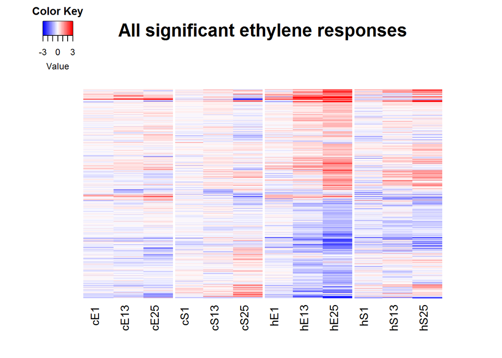

```r
heatcol <- colorRampPalette(c("blue", "white", "red"))

hmAll <- as.matrix(resultsEt[,c("coCE15_logFC", "coCE135_logFC", "coCE255_logFC",
                                 "coCS15_logFC", "coCS135_logFC", "coCS255_logFC",
                                 "hyCE15_logFC", "hyCE135_logFC", "hyCE255_logFC",
                                 "hyCS15_logFC", "hyCS135_logFC", "hyCS255_logFC")])

heatmap.2(hmAll,
          labCol = c("cE1", "cE13", "cE25",
                     "cS1", "cS13", "cS25",
                     "hE1", "hE13", "hE25",
                     "hS1", "hS13", "hS25"),
          srtCol = 90,
          adjCol = c(0.8, 0),
          labRow = NA,
          Colv = FALSE,
          dendrogram = "none",
          trace = "none",
          keysize = 1,
          density.info = "none",
          colsep = c(3, 6, 9),
          breaks = seq(-3, 3, by = 0.2),
          col = heatcol(30),
          main = "All significant ethylene responses",
          lhei = c(1,3),
          lwid = c(1,5)
          )
```

The cotyledon response was not as dramatic as the hypocotyl response, although the direction and pattern of change is similar in both. Therefore, we used only the hypocotyl samples for the remainder of the analysis.

## Hypocotyl only

For the remainder of the analysis, we created a data frame containing only genes which responded to ethylene in the hypocotyl samples.

```r
resultsHy <- resultsEt[unique(c(which(resultsEt$hyCE15_adj.P.Val <= 0.05 & abs(resultsEt$hyCE15_logFC) >= logcut),
                                which(resultsEt$hyCE135_adj.P.Val <= 0.05 & abs(resultsEt$hyCE135_logFC) >= logcut),
                                which(resultsEt$hyCE255_adj.P.Val <= 0.05 & abs(resultsEt$hyCE255_logFC) >= logcut))),]
```

# Compare ethylene & shade responses

The final goal of the analysis was to examine the similarity of response in ethylene- and shade-treated plants, so we created a summary column which summarizes what happens to each gene in these two conditions.

```r
# Create a summary column for what happens in each treatment
resultsHy$ShadeDE <- NA

for (i in 1:length(rownames(resultsHy)))
{
  if(resultsHy$hyCS15_adj.P.Val[i] <= 0.05 |
     resultsHy$hyCS135_adj.P.Val[i] <= 0.05 |
     resultsHy$hyCS255_adj.P.Val[i] <= 0.05)
  {
    if(resultsHy$hyCS255_logFC[i] > 0 & resultsHy$hyCE255_logFC[i] > 0)
    {
      resultsHy$ShadeDE[i] <- "1 BothUp"
    }
    if(resultsHy$hyCS255_logFC[i] > 0 & resultsHy$hyCE255_logFC[i] < 0)
    {
      resultsHy$ShadeDE[i] <- "4 OppShUp"
    }
    if(resultsHy$hyCS255_logFC[i] < 0 & resultsHy$hyCE255_logFC[i] < 0)
    {
      resultsHy$ShadeDE[i] <- "2 BothDown"
    }
    if(resultsHy$hyCS255_logFC[i] < 0 & resultsHy$hyCE255_logFC[i] > 0)
    {
      resultsHy$ShadeDE[i] <- "3 OppEtUp"
    }
  }

  else
  {
    if(resultsHy$hyCE255_logFC[i] > 0)
    {
      resultsHy$ShadeDE[i] <- "5 EtUpOnly"
    }
    if(resultsHy$hyCE255_logFC[i] < 0)
    {
      resultsHy$ShadeDE[i] <- "6 EtDownOnly"
    }
  }
}

# Count size of different groups
table(factor(resultsHy$ShadeDE))
```

```
##
##     1 BothUp   2 BothDown    3 OppEtUp    4 OppShUp   5 EtUpOnly
##         1718         1701          425          395         1477
## 6 EtDownOnly
##         1532
```

## Heatmap

For this hypocotyl-specific heatmap, we used the `Heatmap` function from the `ComplexHeatmaps` package, which enabled us to separate the heatmap by the groups from the summary column above.

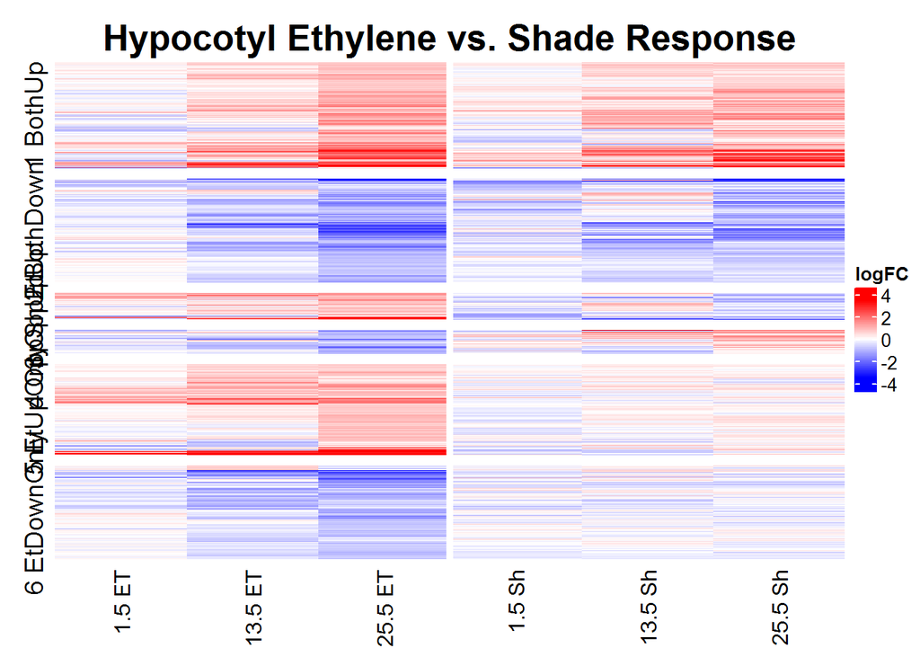

```r
# Set up data frame for heatmap.
hmHy <- resultsHy[,c("hyCE15_logFC", "hyCE135_logFC", "hyCE255_logFC",
                     "hyCS15_logFC", "hyCS135_logFC", "hyCS255_logFC",
                     "ShadeDE"
                     )]

colnames(hmHy)[1:6] <- c("1.5 ET", "13.5 ET", "25.5 ET", "1.5 Sh", "13.5 Sh", "25.5 Sh")

# Create color scale
brks <- seq(-3, 3, by = 0.2)
heatcol <- colorRampPalette(c("blue", "white", "red"))

Heatmap(
  # What to plot
  as.matrix(hmHy[,1:6]),
  # Splitting on groups
  split = hmHy$ShadeDE,
  gap = unit(2, "mm"),
  # Color scale
  col = colorRamp2(brks, heatcol(length(brks))),
  # Dendrogram
  cluster_columns = FALSE,
  show_row_dend = FALSE,
  # Labels
  column_title = "Hypocotyl Ethylene vs. Shade Response",
  column_title_gp = gpar(fontsize = 20, fontface = "bold"),
  name = "logFC",
  show_row_names = FALSE
)

# Add 'spacer' line between ethylene and shade columns
decorate_heatmap_body("logFC",
                      {grid.lines(c(0.5, 0.5), c(0, 1), gp = gpar(lwd = 5, col = "white"))},
                      slice = 1)
decorate_heatmap_body("logFC",
                      {grid.lines(c(0.5, 0.5), c(0, 1), gp = gpar(lwd = 5, col = "white"))},
                      slice = 2)
decorate_heatmap_body("logFC",
                      {grid.lines(c(0.5, 0.5), c(0, 1), gp = gpar(lwd = 5, col = "white"))},
                      slice = 3)
decorate_heatmap_body("logFC",
                      {grid.lines(c(0.5, 0.5), c(0, 1), gp = gpar(lwd = 5, col = "white"))},
                      slice = 4)
decorate_heatmap_body("logFC",
                      {grid.lines(c(0.5, 0.5), c(0, 1), gp = gpar(lwd = 5, col = "white"))},
                      slice = 5)
decorate_heatmap_body("logFC",
                      {grid.lines(c(0.5, 0.5), c(0, 1), gp = gpar(lwd = 5, col = "white"))},
                      slice = 6)
```

## Plot 25.5 hour time point

We then plotted the data from the 25.5 hour time point alone. We excluded genes which were ethylene regulated at 1.5 or 13.5 hours, but not at 25.5 hours.

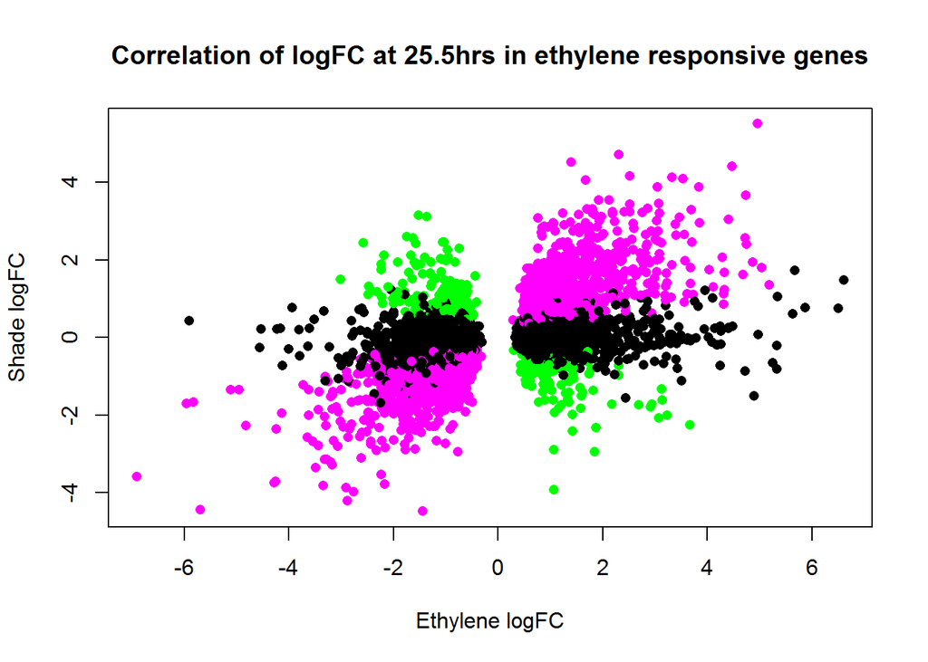

```r
# Create a summary column for the 25.5 hour time point
resultsHy$DE225 <- NA

for (i in 1:length(rownames(resultsHy)))
{
  if(resultsHy$hyCE255_adj.P.Val[i] <= 0.05)
  {
    if(resultsHy$hyCS255_adj.P.Val[i] <= 0.05)
    {
      resultsHy$DE225[i] <- "Both"
    }

    else
    {
      resultsHy$DE225[i] <- "Ethylene"
    }
  }

  else
  {
    resultsHy$DE225[i] <- "Not ethylene DE"
  }
}

# Get only genes which are DE at 225
resultsHy225 <- resultsHy[which(resultsHy$DE225 == "Ethylene" |
                                  resultsHy$DE225 == "Both"),
                          c(1, 23:28)]

## Plot 25.5hr genes ####
plot(resultsHy225$hyCE255_logFC, resultsHy225$hyCS255_logFC,
     main = "Correlation of logFC at 25.5hrs in ethylene responsive genes",
     xlab = "Ethylene logFC",
     ylab = "Shade logFC",
     pch = 16,
     col = ifelse(resultsHy225$DE225 == "Ethylene", "black",
                  ifelse((resultsHy225$hyCE255_logFC > 0 & resultsHy225$hyCS255_logFC > 0) |
                           (resultsHy225$hyCE255_logFC < 0 & resultsHy225$hyCS255_logFC < 0),
                         "magenta", "green"))
)
```

```r
# Quantify results
table(factor(resultsHy225$ShadeDE))
```

```
##
##     1 BothUp   2 BothDown    3 OppEtUp    4 OppShUp   5 EtUpOnly
##         1586         1519          313          297         1240
## 6 EtDownOnly
##         1258
```

## Calculate correlation coefficients

Finally, we calculated the correlation coefficients for two groups, those that had the same direction of response in ethylene and shade (positive correlation) and those that had the opposite direction of response (negative correlation)

```r
# Positive correlation
cor.test(resultsHy225[which(resultsHy225$DE225 == "Both" &
                          (resultsHy225$ShadeDE == "1 BothUp" |
                             resultsHy225$ShadeDE == "2 BothDown")),
                      "hyCE255_logFC"],
         resultsHy225[which(resultsHy225$DE225 == "Both" &
                              (resultsHy225$ShadeDE == "1 BothUp" |
                                 resultsHy225$ShadeDE == "2 BothDown")),
                      "hyCS255_logFC"],
         "greater", "pearson")
```

```
##
##  Pearson's product-moment correlation
##
## data:  resultsHy225[which(resultsHy225$DE225 == "Both" & (resultsHy225$ShadeDE ==  and resultsHy225[which(resultsHy225$DE225 == "Both" & (resultsHy225$ShadeDE ==     "1 BothUp" | resultsHy225$ShadeDE == "2 BothDown")), "hyCE255_logFC"] and     "1 BothUp" | resultsHy225$ShadeDE == "2 BothDown")), …
## t = 94.743, df = 2434, p-value < 2.2e-16
## alternative hypothesis: true correlation is greater than 0
## 95 percent confidence interval:
##  0.8796235 1.0000000
## sample estimates:
##      cor
## 0.886951
```

```r
# Negative correlation
cor.test(resultsHy225[which(resultsHy225$DE225 == "Both" &
                              (resultsHy225$ShadeDE == "3 OppEtUp" |
                                 resultsHy225$ShadeDE == "4 OppShUp")),
                      "hyCE255_logFC"],
         resultsHy225[which(resultsHy225$DE225 == "Both" &
                              (resultsHy225$ShadeDE == "3 OppEtUp" |
                                 resultsHy225$ShadeDE == "4 OppShUp")),
                      "hyCS255_logFC"],
         "greater", "pearson")
```

```
##
##  Pearson's product-moment correlation
##
## data:  resultsHy225[which(resultsHy225$DE225 == "Both" & (resultsHy225$ShadeDE ==  and resultsHy225[which(resultsHy225$DE225 == "Both" & (resultsHy225$ShadeDE ==     "3 OppEtUp" | resultsHy225$ShadeDE == "4 OppShUp")), "hyCE255_logFC"] and     "3 OppEtUp" | resultsHy225$ShadeDE == "4 OppShUp")), …
## t = -30.083, df = 282, p-value = 1
## alternative hypothesis: true correlation is greater than 0
## 95 percent confidence interval:
##  -0.8945771  1.0000000
## sample estimates:
##       cor
## -0.873168
```

# Session Info